# business_forecasting_assignment06

Adwait Kalsekar

2023-11-21

# ARIMA Model

### Importing Libraries

```r
library(fpp)
library(fpp2)
library(forecast)
```

### Reading Dataset

```r
df <- read.csv("NJ_HPI.csv")
head(df)
```

```
##         DATE HPI.NJ
## 1 1975-01-01  64.32
## 2 1975-04-01  59.29
## 3 1975-07-01  60.10
## 4 1975-10-01  62.81
## 5 1976-01-01  62.79
## 6 1976-04-01  63.85
```

### Converting to Time Series

```r
df_ts <- ts(df$HPI.NJ, start=c(1975, 1), end=c(2023, 2), frequency=4)
head(df_ts)
```

```
##       Qtr1  Qtr2  Qtr3  Qtr4
## 1975 64.32 59.29 60.10 62.81
## 1976 62.79 63.85
```

### Plotting the Time Series

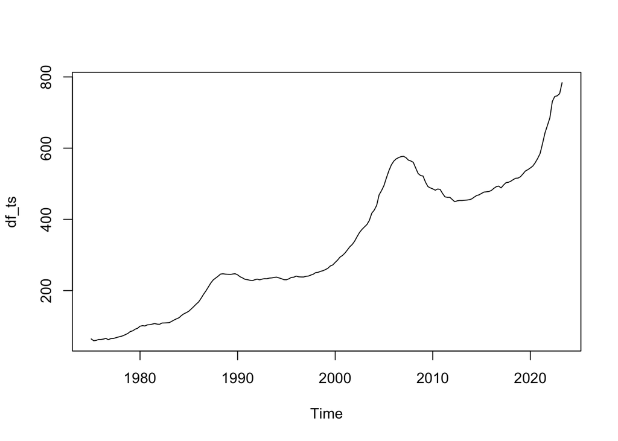

```r
plot(df_ts)
```

### Finding Number of differences required for a stationary series

```r
ndiffs(df_ts)
```

```
## [1] 1
```

### Finding Number of differences required for a seasonally stationary series

```r
nsdiffs(df_ts)
```

```
## [1] 0
```

### Plotting ACF and PACF for the Time Series

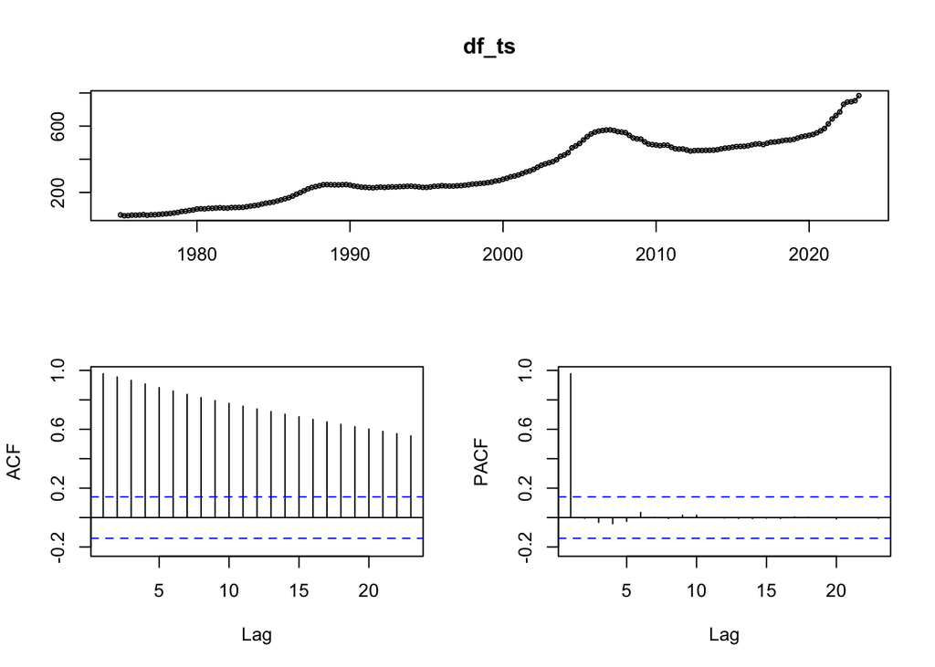

```r
tsdisplay(df_ts)
```

### Setting Diff 1

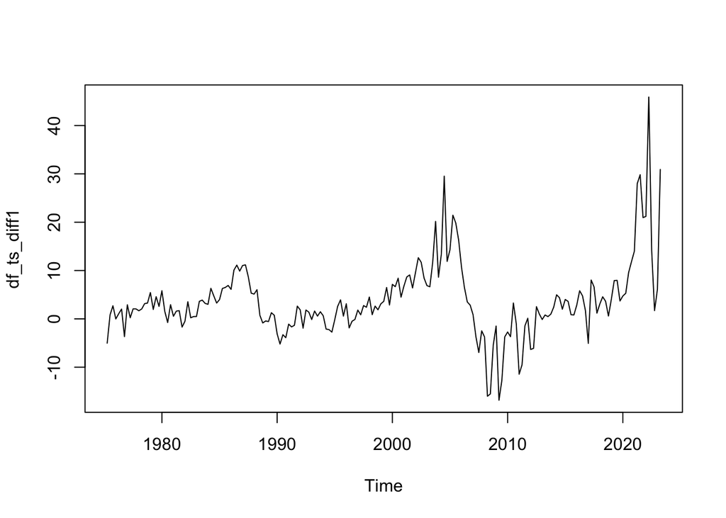

```r
df_ts_diff1 <- diff(df_ts, 1)
plot(df_ts_diff1)
```

### Plotting ACF and PACF for the Time Series with Diff 1

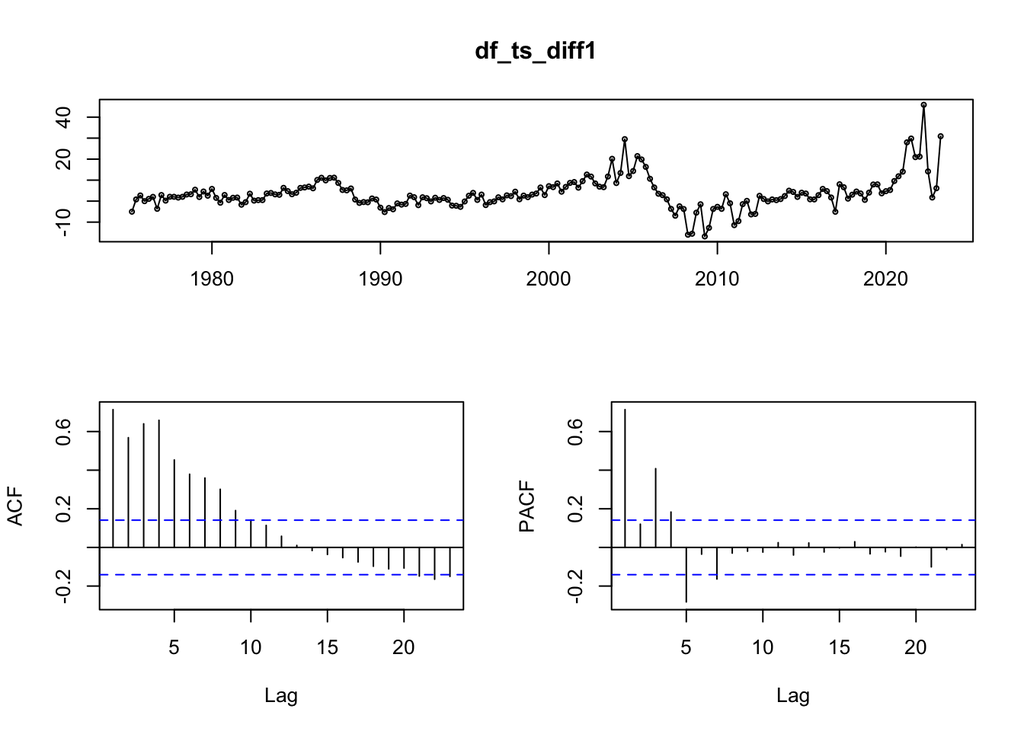

```r
tsdisplay(df_ts_diff1)
```

### ARIMA Model

```r
df_ts_arima <- auto.arima(df_ts, trace = TRUE, stepwise = FALSE)
```

```
##
##  Fitting models using approximations to speed things up...
##
##  ARIMA(0,1,0)                              : 1373.317
##  ARIMA(0,1,0)           with drift         : 1334.541
##  ARIMA(0,1,0)(0,0,1)[4]                    : 1263.339
##  ARIMA(0,1,0)(0,0,1)[4] with drift         : 1240.542
##  ARIMA(0,1,0)(0,0,2)[4]                    : 1227.924
##  ARIMA(0,1,0)(0,0,2)[4] with drift         : 1214.536
##  ARIMA(0,1,0)(1,0,0)[4]                    : 1221.387
##  ARIMA(0,1,0)(1,0,0)[4] with drift         : 1215.132
##  ARIMA(0,1,0)(1,0,1)[4]                    : 1220.045
##  ARIMA(0,1,0)(1,0,1)[4] with drift         : 1212.388
##  ARIMA(0,1,0)(1,0,2)[4]                    : 1219.998
##  ARIMA(0,1,0)(1,0,2)[4] with drift         : 1211.508
##  ARIMA(0,1,0)(2,0,0)[4]                    : 1221.389
##  ARIMA(0,1,0)(2,0,0)[4] with drift         : 1212.631
##  ARIMA(0,1,0)(2,0,1)[4]                    : 1223.444
##  ARIMA(0,1,0)(2,0,1)[4] with drift         : 1208.122
##  ARIMA(0,1,0)(2,0,2)[4]                    : 1223.878
##  ARIMA(0,1,0)(2,0,2)[4] with drift         : 1214.931
##  ARIMA(0,1,1)                              : 1257.598
##  ARIMA(0,1,1)           with drift         : 1232.85
##  ARIMA(0,1,1)(0,0,1)[4]                    : 1186.098
##  ARIMA(0,1,1)(0,0,1)[4] with drift         : 1172.712
##  ARIMA(0,1,1)(0,0,2)[4]                    : 1159.653
##  ARIMA(0,1,1)(0,0,2)[4] with drift         : 1151.805
##  ARIMA(0,1,1)(1,0,0)[4]                    : 1153.663
##  ARIMA(0,1,1)(1,0,0)[4] with drift         : 1149.013
##  ARIMA(0,1,1)(1,0,1)[4]                    : 1155.735
##  ARIMA(0,1,1)(1,0,1)[4] with drift         : 1150.872
##  ARIMA(0,1,1)(1,0,2)[4]                    : 1155.4
##  ARIMA(0,1,1)(1,0,2)[4] with drift         : 1149.895
##  ARIMA(0,1,1)(2,0,0)[4]                    : 1155.841
##  ARIMA(0,1,1)(2,0,0)[4] with drift         : 1150.867
##  ARIMA(0,1,1)(2,0,1)[4]                    : 1156.474
##  ARIMA(0,1,1)(2,0,1)[4] with drift         : 1152.088
##  ARIMA(0,1,1)(2,0,2)[4]                    : 1156.791
##  ARIMA(0,1,1)(2,0,2)[4] with drift         : 1151.478
##  ARIMA(0,1,2)                              : 1220.235
```

[output cut: 127 more lines]

```
##  ARIMA(3,1,1)                              : 1145.902
##  ARIMA(3,1,1)           with drift         : 1145.951
##  ARIMA(3,1,1)(0,0,1)[4]                    : 1136.028
##  ARIMA(3,1,1)(0,0,1)[4] with drift         : 1135.52
##  ARIMA(3,1,1)(1,0,0)[4]                    : 1130.376
##  ARIMA(3,1,1)(1,0,0)[4] with drift         : 1129.595
##  ARIMA(3,1,2)                              : 1137.398
##  ARIMA(3,1,2)           with drift         : 1136.84
##
##  Now re-fitting the best model(s) without approximations...
##
##
##
##
##  Best model: ARIMA(3,1,0)(0,0,2)[4] with drift
```

```r
df_ts_arima
```

```
## Series: df_ts
## ARIMA(3,1,0)(0,0,2)[4] with drift
##
## Coefficients:
##          ar1      ar2     ar3    sma1    sma2   drift
##       0.5892  -0.1412  0.3128  0.3821  0.2368  3.6863
## s.e.  0.0729   0.0850  0.0756  0.0866  0.0916  2.0591
##
## sigma^2 = 19.8:  log likelihood = -560.05
## AIC=1134.11   AICc=1134.71   BIC=1156.95
```

#### Analysis:

> The best model comes out to be ARIMA(3,1,0)(0,0,2)[4]  
> Which is of the form ARIMA(p,d,q)(P,D,Q)[s], where,
- p: The order of the autoregressive (AR) component
- d: The degree of differencing (the number of times the series is differenced to achieve stationarity)
- q: The order of the moving average (MA) component
- P: The seasonal order of the autoregressive component
- D: The seasonal order of differencing
- Q: The seasonal order of the moving average component
- s: The length of the seasonal cycle

> Looking at the Best model, it can be inferred that the model has:
- An autoregressive component of order 3
- A first-order differencing to make the series stationary
- A moving average component of order 0
- A seasonal moving average component of order 2
- A seasonal cycle of length 4

### Residual Analysis

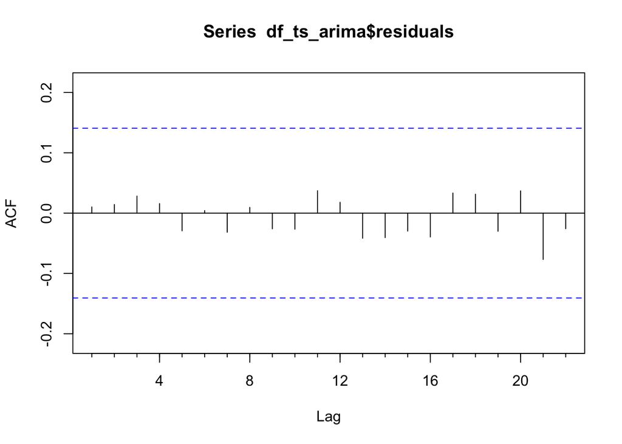

```r
Acf(df_ts_arima$residuals)
```

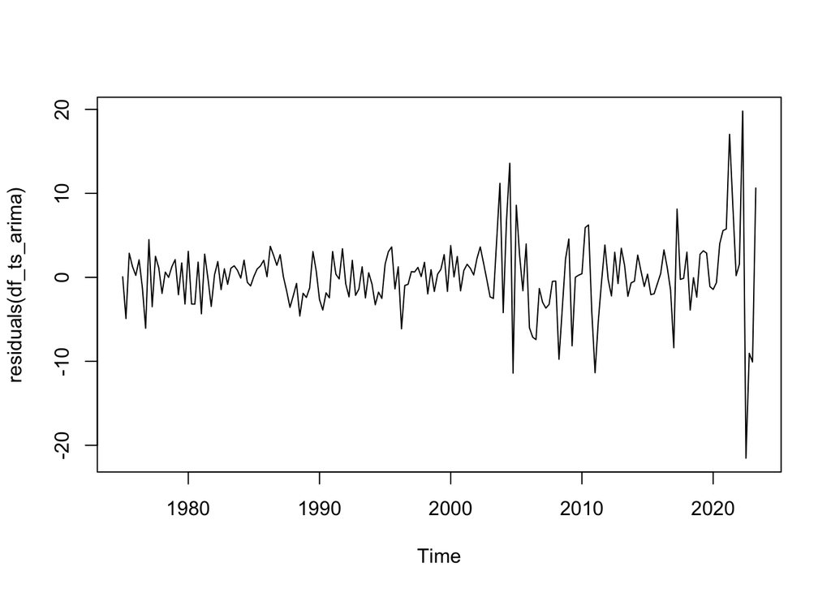

```r
plot.ts(residuals(df_ts_arima))
```

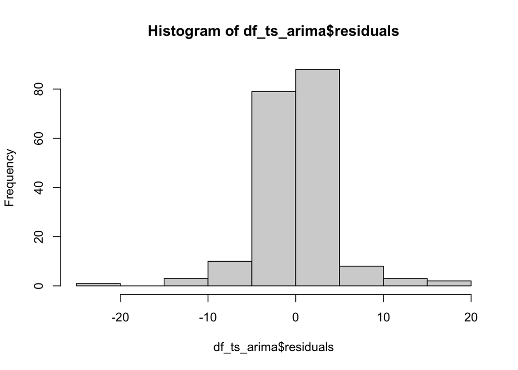

```r
hist(df_ts_arima$residuals)
```

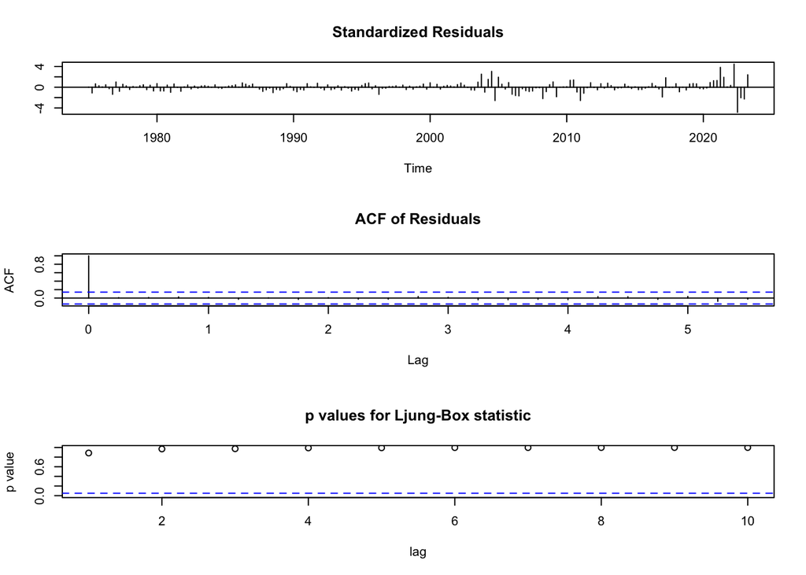

```r
tsdiag(df_ts_arima)
```

#### Interpretation:

> Looking at the residuals we can see that the residuals are normally distributed with mean close to 0.  
> Also the Acf shows no correlation between the residuals.  
> There is no observable pattern in the plot of residuals.  
> Hence, we can confirm that there is no more data to be extracted from the residuals.

### Forecasts from ARIMA Model for next 5 periods

```r
attributes(df_ts_arima)
```

```
## $names
##  [1] "coef"      "sigma2"    "var.coef"  "mask"      "loglik"    "aic"
##  [7] "arma"      "residuals" "call"      "series"    "code"      "n.cond"
## [13] "nobs"      "model"     "xreg"      "bic"       "aicc"      "x"
## [19] "fitted"
##
## $class
## [1] "forecast_ARIMA" "ARIMA"          "Arima"
```

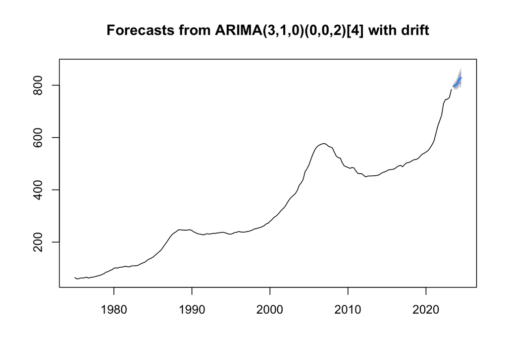

```r
df_ts_arima_forecast <- forecast(df_ts_arima, h=5)
plot(df_ts_arima_forecast)
```

### Accuracy Measures

```r
accuracy(df_ts_arima_forecast)
```

```
##                      ME     RMSE      MAE          MPE     MAPE      MASE
## Training set 0.05943872 4.368232 2.892758 -0.009792197 1.108256 0.1392334
##                    ACF1
## Training set 0.01024078
```